# Self-Driving Car Engineer Nanodegree

### Analyze Performance

```
Actual class:  Double curve
```

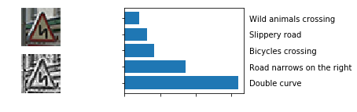

```
---------------------------------------------------------------------------------------------------

Actual class:  Keep left
```

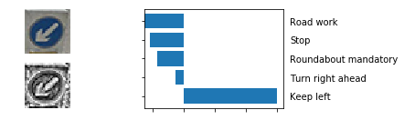

```
---------------------------------------------------------------------------------------------------

Actual class:  No entry
```

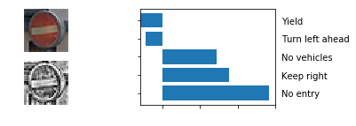

```
---------------------------------------------------------------------------------------------------

Actual class:  No entry
```

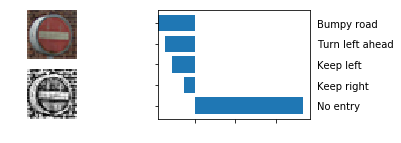

```
---------------------------------------------------------------------------------------------------

Actual class:  No entry
```

[figure not shown]

```
---------------------------------------------------------------------------------------------------

Actual class:  Keep left
```

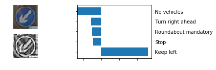

```
---------------------------------------------------------------------------------------------------

Actual class:  Keep left
```

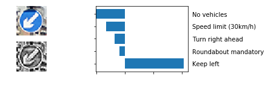

```
---------------------------------------------------------------------------------------------------

Actual class:  Roundabout mandatory
```

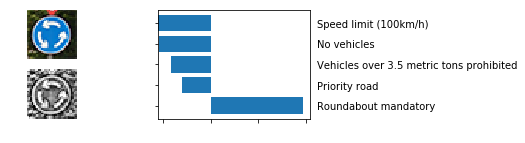

```
---------------------------------------------------------------------------------------------------

Actual class:  Roundabout mandatory
```

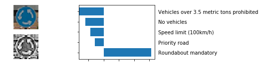

```
---------------------------------------------------------------------------------------------------

Actual class:  Turn left ahead
```

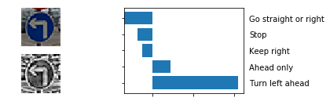

```
---------------------------------------------------------------------------------------------------

Actual class:  Children crossing
```

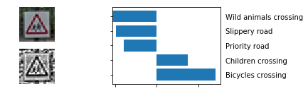

```
---------------------------------------------------------------------------------------------------

Actual class:  Keep left
```

[figure not shown]

```
---------------------------------------------------------------------------------------------------

Actual class:  Speed limit (20km/h)
```

[31 more figures not shown]

```python
### Calculate the accuracy for these 43 new images.
### For example, if the model predicted 1 out of 5 signs correctly, it's 20% accurate on these new images.
# print(new_pics_classes)

def plot_image_statistics(predictions, index):
    # Prepare original and preprocessed images
    original = io.imread(os.getcwd() + '/additional_images/' + "example_{0:0>5}".format(index + 1) + '.png')
    preprocessed = X_custom[index].reshape(32, 32)

    # Prepare the grid
    pyplot.figure(figsize = (6, 2))
    gridspec.GridSpec(2, 2)

    # Plot original image
    pyplot.subplot2grid((2, 2), (0, 0), colspan=1, rowspan=1)
    pyplot.imshow(original)
    pyplot.axis('off')

    # Plot preprocessed image
    pyplot.subplot2grid((2, 2), (1, 0), colspan=1, rowspan=1)
    pyplot.imshow(preprocessed, cmap='gray')
    pyplot.axis('off')

    # Plot predictions
    pyplot.subplot2grid((2, 2), (0, 1), colspan=1, rowspan=2)
    pyplot.barh(np.arange(5)+.5, predictions[0][index], align='center')
    pyplot.yticks(np.arange(5)+.5, signnames[predictions[1][index].astype(int)])
    pyplot.tick_params(axis='both', which='both', labelleft='off', labelright='on', labeltop='off', labelbottom='off')

    pyplot.show()

with tf.Session() as sess:
    predicts = sess.run(tf.nn.top_k(new_pics_classes, k=5, sorted=True))

# For every example plot original image, preprocessed image, and model predictions.
for i in range(43):
    print("Actual class: ", signnames[y_custom[i]] if y_custom[i] != 99 else "None")
    plot_image_statistics(predicts, i)
    print("---------------------------------------------------------------------------------------------------\n")
```

```python
num_of_images = 0
correct = 0
for i in range(43):
    index = np.argmax(predicts[0][i])
    output = y_custom[i]
    prediction = predicts[1][i][index]
#     print(y_custom[i], prediction)
    if output == 99:
        continue

    if prediction == output:
        correct += 1

    num_of_images += 1

print(num_of_images)
print(correct)
accuracy = 100.0 * correct / num_of_images
print("Accuracy on captured images: %.2f%%" % (accuracy))
```

```
40
34
Accuracy on captured images: 85.00%
```

For each of the new images, print out the model's softmax probabilities to show the **certainty** of the model's predictions (limit the output to the top 5 probabilities for each image). [`tf.nn.top_k`](https://www.tensorflow.org/versions/r0.12/api_docs/python/nn.html#top_k) could prove helpful here.

The example below demonstrates how tf.nn.top_k can be used to find the top k predictions for each image.

`tf.nn.top_k` will return the values and indices (class ids) of the top k predictions. So if k=3, for each sign, it'll return the 3 largest probabilities (out of a possible 43) and the correspoding class ids.

Take this numpy array as an example. The values in the array represent predictions. The array contains softmax probabilities for five candidate images with six possible classes. `tk.nn.top_k` is used to choose the three classes with the highest probability:

```
# (5, 6) array
a = np.array([[ 0.24879643,  0.07032244,  0.12641572,  0.34763842,  0.07893497,
         0.12789202],
       [ 0.28086119,  0.27569815,  0.08594638,  0.0178669 ,  0.18063401,
         0.15899337],
       [ 0.26076848,  0.23664738,  0.08020603,  0.07001922,  0.1134371 ,
         0.23892179],
       [ 0.11943333,  0.29198961,  0.02605103,  0.26234032,  0.1351348 ,
         0.16505091],
       [ 0.09561176,  0.34396535,  0.0643941 ,  0.16240774,  0.24206137,
         0.09155967]])
```

Running it through `sess.run(tf.nn.top_k(tf.constant(a), k=3))` produces:

```
TopKV2(values=array([[ 0.34763842,  0.24879643,  0.12789202],
       [ 0.28086119,  0.27569815,  0.18063401],
       [ 0.26076848,  0.23892179,  0.23664738],
       [ 0.29198961,  0.26234032,  0.16505091],
       [ 0.34396535,  0.24206137,  0.16240774]]), indices=array([[3, 0, 5],
       [0, 1, 4],
       [0, 5, 1],
       [1, 3, 5],
       [1, 4, 3]], dtype=int32))
```

Looking just at the first row we get `[ 0.34763842, 0.24879643, 0.12789202]`, you can confirm these are the 3 largest probabilities in `a`. You'll also notice `[3, 0, 5]` are the corresponding indices.

```python
### Print out the top five softmax probabilities for the predictions on the German traffic sign images found on the web.
### Feel free to use as many code cells as needed.
for i in range(len(predicts[0])):
    print('Image', i, 'probabilities:', predicts[0][i], '\n and predicted classes:', predicts[1][i])
```

```
Image 0 probabilities: [ 15.96349716   8.61983681   4.13030005   3.14434576   2.06234956]
 and predicted classes: [21 24 29 23 31]
Image 1 probabilities: [ 30.13975525  -2.40333748  -8.28664112 -10.78820229 -12.46235371]
 and predicted classes: [39 33 40 14 25]
Image 2 probabilities: [ 5.66320229  3.5413394   2.89596939 -0.89382553 -1.16503572]
 and predicted classes: [17 38 15 34 13]
Image 3 probabilities: [ 26.55574417  -2.62297726  -5.41310596  -7.25108433  -8.89030933]
 and predicted classes: [17 38 39 34 22]
Image 4 probabilities: [ 36.44133759   2.42045283  -1.99726439  -6.63188314 -10.789217  ]
 and predicted classes: [17 32 34 38  9]
Image 5 probabilities: [ 25.90877342  -4.73605061  -5.16706753  -5.69226313 -13.31800175]
 and predicted classes: [39 14 40 33 15]
Image 6 probabilities: [ 20.65011787  -1.89501977  -3.67603397  -6.67904615 -10.25451851]
 and predicted classes: [39 40 33  1 15]
Image 7 probabilities: [ 19.45812988  -6.06057596  -8.29886723 -10.83451271 -10.9952879 ]
 and predicted classes: [40 12 16 15  7]
Image 8 probabilities: [ 15.64240456  -2.97680998  -4.40859461  -6.06124687  -8.14956665]
 and predicted classes: [40 12  7 15 16]
Image 9 probabilities: [ 20.94505501   4.47583437  -2.39272404  -3.57605171  -6.86488199]
 and predicted classes: [34 35 38 14 36]
Image 10 probabilities: [ 14.18198109   7.53954268  -7.81893301  -9.78938103 -10.59381485]
 and predicted classes: [29 28 12 23 31]
Image 11 probabilities: [ 34.70941925  -5.24069738  -8.37530518 -11.42801571 -11.55268478]
 and predicted classes: [39 14 40 31 33]
Image 12 probabilities: [ 13.34146976   0.04663901  -3.00970745  -5.16559458  -5.61206579]
 and predicted classes: [ 0  1  8 36 14]
Image 13 probabilities: [ 39.63303757   1.87168002  -2.88303351  -3.03833008  -6.0207653 ]
 and predicted classes: [17 32 38 34  9]
Image 14 probabilities: [ 21.18814659   7.92001772  -1.02338171  -9.77383518 -10.75252056]
 and predicted classes: [38 13 19  1 15]
Image 15 probabilities: [ 39.20597839   0.56948543  -7.74305916  -8.36573601 -10.75552082]
 and predicted classes: [13 12 15 35 37]
Image 16 probabilities: [ 2.21935534  1.99197662  1.053936    0.69500852  0.43380666]
 and predicted classes: [ 5  7  2 12 40]
Image 17 probabilities: [ 51.77723312   4.22901869  -8.20304585  -8.56902885 -18.870924  ]
 and predicted classes: [13 12 15 35  1]
Image 18 probabilities: [ 23.71725273  -4.44266891  -5.99578094  -8.07870197  -9.23605728]
 and predicted classes: [38 20 17 14 18]
Image 19 probabilities: [ 24.97473717  -7.59693384  -7.94509315  -9.74187088 -11.66107464]
 and predicted classes: [38 14 18 15 17]
```

[output cut: 31 more lines]

```
 and predicted classes: [ 0  3  1 36 34]
Image 36 probabilities: [ 4.29055071  0.86308688 -2.01765227 -3.03619957 -6.14803219]
 and predicted classes: [ 0  3 14  8 36]
Image 37 probabilities: [ 10.96733952   1.57394254  -0.03853452  -3.61352396  -5.26650667]
 and predicted classes: [ 0  1 14  5  8]
Image 38 probabilities: [ 12.41706657  -0.82651496  -7.12568045  -8.6019392  -12.12601471]
 and predicted classes: [ 3  5 35  2 12]
Image 39 probabilities: [ 24.05613899  14.84720898   0.65054893  -1.04320621  -9.66402245]
 and predicted classes: [34 38 14 36  0]
Image 40 probabilities: [ 9.75721455  7.71001863 -0.36896348 -3.84844303 -8.11573601]
 and predicted classes: [ 3 14  1  5 11]
Image 41 probabilities: [ 7.67499971  3.5723238  -0.54444885 -1.52442193 -1.83363986]
 and predicted classes: [18 24 25 26  4]
Image 42 probabilities: [ 11.41377831   1.7426852    0.76027405  -3.29413891  -4.44476891]
 and predicted classes: [13 12 40 38  2]
```

## Step 4: Visualize the Neural Network's State with Test Images

This Section is not required to complete but acts as an additional excersise for understaning the output of a neural network's weights. While neural networks can be a great learning device they are often referred to as a black box. We can understand what the weights of a neural network look like better by plotting their feature maps. After successfully training your neural network you can see what it's feature maps look like by plotting the output of the network's weight layers in response to a test stimuli image. From these plotted feature maps, it's possible to see what characteristics of an image the network finds interesting. For a sign, maybe the inner network feature maps react with high activation to the sign's boundary outline or to the contrast in the sign's painted symbol.

Provided for you below is the function code that allows you to get the visualization output of any tensorflow weight layer you want. The inputs to the function should be a stimuli image, one used during training or a new one you provided, and then the tensorflow variable name that represents the layer's state during the training process, for instance if you wanted to see what the LeNet lab's feature maps looked like for it's second convolutional layer you could enter conv2 as the tf_activation variable.

For an example of what feature map outputs look like, check out NVIDIA's results in their paper [End-to-End Deep Learning for Self-Driving Cars](https://devblogs.nvidia.com/parallelforall/deep-learning-self-driving-cars/) in the section Visualization of internal CNN State. NVIDIA was able to show that their network's inner weights had high activations to road boundary lines by comparing feature maps from an image with a clear path to one without. Try experimenting with a similar test to show that your trained network's weights are looking for interesting features, whether it's looking at differences in feature maps from images with or without a sign, or even what feature maps look like in a trained network vs a completely untrained one on the same sign image.

[figure not shown]

Your output should look something like this (above)

```python
### Visualize your network's feature maps here.
### Feel free to use as many code cells as needed.

# image_input: the test image being fed into the network to produce the feature maps
# tf_activation: should be a tf variable name used during your training procedure that represents the calculated state of a specific weight layer
# activation_min/max: can be used to view the activation contrast in more detail, by default matplot sets min and max to the actual min and max values of the output
# plt_num: used to plot out multiple different weight feature map sets on the same block, just extend the plt number for each new feature map entry

def outputFeatureMap(image_input, tf_activation, activation_min=-1, activation_max=-1 ,plt_num=1):
    # Here make sure to preprocess your image_input in a way your network expects
    # with size, normalization, ect if needed
    # image_input =
    # Note: x should be the same name as your network's tensorflow data placeholder variable
    # If you get an error tf_activation is not defined it maybe having trouble accessing the variable from inside a function
    activation = tf_activation.eval(session=sess,feed_dict={x : image_input})
    featuremaps = activation.shape[3]
    pyplot.figure(plt_num, figsize=(15,15))
    for featuremap in range(featuremaps):
        pyplot.subplot(6,8, featuremap+1) # sets the number of feature maps to show on each row and column
        pyplot.title('FeatureMap ' + str(featuremap)) # displays the feature map number
        if activation_min != -1 & activation_max != -1:
            pyplot.imshow(activation[0,:,:, featuremap], interpolation="nearest", vmin =activation_min, vmax=activation_max, cmap="gray")
        elif activation_max != -1:
            pyplot.imshow(activation[0,:,:, featuremap], interpolation="nearest", vmax=activation_max, cmap="gray")
        elif activation_min !=-1:
            pyplot.imshow(activation[0,:,:, featuremap], interpolation="nearest", vmin=activation_min, cmap="gray")
        else:
            pyplot.imshow(activation[0,:,:, featuremap], interpolation="nearest", cmap="gray")
```

```python
image = X_custom[0].squeeze()
pyplot.figure(figsize=(1,1))
pyplot.imshow(image, cmap="gray")
```

[output not shown]

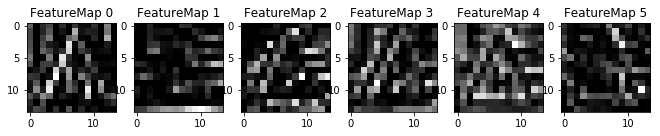

```python
with tf.Session() as sess:
    saver.restore(sess, './' + save_file)
    outputFeatureMap([X_custom[0]], conv_layer1)
```

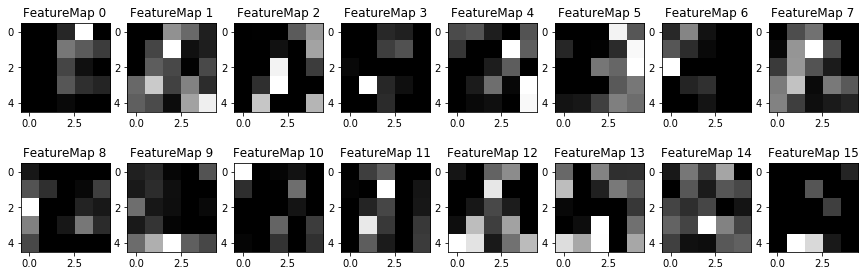

```python
with tf.Session() as sess:
    saver.restore(sess, './' + save_file)
    outputFeatureMap([X_custom[0]], conv_layer2)
```

### Project Writeup

Once you have completed the code implementation, document your results in a project writeup using this [template](https://github.com/udacity/CarND-Traffic-Sign-Classifier-Project/blob/master/writeup_template.md) as a guide. The writeup can be in a markdown or pdf file.